# Data cleaning, descriptives, reliability, histograms, correlations

# Load packages and data

```r
library(tidyverse)
library(sjmisc)
library(haven)
library(easystats)
library(purrr)
library(psych)
library(gridExtra)
library(lme4)
library(lmerTest)
library(broom)
```

Load apps dataset, which contains LADI coding information and relevant variables [code not displayed for peer review]

Load full dataset to use for reporting demographics, calculating reliability, and pulling variables not included in prior apps dataset when initially requested. [code not displayed for peer review]

Reduce full dataset to the n=57 people who had coded data for this study.

```r
id <- select(apps, ParticipantID)
# create a variable denoting who was included in this study vs not for descriptive comparisons, put in new dataframe
comp <- full |>
  mutate(analytic_yn = if_else(ParticipantID %in% id$ParticipantID, T, F))

full <- id |> left_join(full, by = "ParticipantID")

rm(id)
```

Merge variables not included in the apps dataset (this includes HIV risk transmission behavior from TLFB, AUDIT, SIDAS, and SIP-AD).

```r
# isolate variables to merge
merge <-
  full |>
  select(ParticipantID, Assessment, Sx_CASriskacts, Sx_totalacts_sum, SIP_sum, AUDIT_sum, SIDAS_sum) |>
  # change Assessment variable to character to match dataset; add in missing variables for BL
  mutate(Assessment = case_when(Assessment == 0 ~ "BL",
                                Assessment == 1 ~ "4M",
                                Assessment == 2 ~ "8M",
                                Assessment == 3 ~ "12M")) |>
  pivot_wider(id_cols = ParticipantID,
              names_from = Assessment,
              values_from = c(-ParticipantID, -Assessment),
              names_sep = ".")
# merge
apps <- left_join(apps, merge, by = "ParticipantID") |>
  # create a variable for whether pt was engaged in CMHT, general MH services, or medication at BL - should be 0 for everyone
  mutate(CMHT.BL = 0,
         MHgen.BL = 0,
         Medication.BL = 0)
rm(merge)
```

# Data restructuring

First we need to re-structure the dataset to long format. One dataframe will contain the outcome/follow-up assessment data, one will contain alliance data. This is done because there are differing numbers of time points - 4 assessments (BL, 4MFU, 8MFU, 12MFU) and 10 sessions.

Because we are interested in controlling for the therapy alliance in analyses, we need to separate out the alliance data and pull the alliance scores for the sessions where the LGBTQ-APPS was coded. This code will do that and merge it with the main dataset before restructuring.

```r
apps <- mutate(apps, WAI_sum_missing = rowSums(is.na(across(WAI_P_Sum.Session1:WAI_P_Sum.Session10))),
         WAI_sum_missing = recode_factor(if_else(WAI_sum_missing > 0, 1, 0), `0` = "No missing data for any session", `1` = "Missing data for at least 1 session")) # create a variable denoting whether participant has complete WAI data or is missing at least one session

apps_alliance <-
  apps |>
  select(ParticipantID, Early_Session, Mid_Session, WAI_P_Sum.Session1:WAI_P_Sum.Session10) |>
  pivot_longer(cols = c(-ParticipantID, -Early_Session, -Mid_Session),
    names_to = c(".value", "Session"),
    names_sep = "\\.Session") |>
  # rename alliance variable
  rename(WAI.Total = WAI_P_Sum)

early <- apps_alliance |> select(ParticipantID, Session, Early_Session, Mid_Session, WAI.Total) |>
  # match the alliance score for the specific session that was coded
  filter(if_else(Early_Session == 3, Session == 3, Session == 2)) |>
  select(ParticipantID, WAI_early = WAI.Total)

mid <- apps_alliance |> select(ParticipantID, Session, Early_Session, Mid_Session, WAI.Total) |>
  # match the alliance score for the specific session that was coded
  filter(if_else(Mid_Session == 5, Session == 5, Session == 6)) |>
  select(ParticipantID, WAI_mid = WAI.Total)

# join the isolated alliance scores with the dataset
apps <- left_join(apps, early, by = "ParticipantID") |>
  left_join(mid, by = "ParticipantID")

# create average across the two sessions
apps <- apps |>
  sjmisc::row_means(WAI_early:WAI_mid, n = 0.5, var = "WAI_avg")

rm(early)
rm(mid)
rm(apps_alliance)

full |>
  select(contains("WAI"))
```

```
# A tibble: 228 × 0
```

Second, separate out outcome data to separate dataframe & pivot to long format.

```r
apps_outcome <- apps |>
  # select out variables for outcome analyses
  select(ParticipantID, TherapistID, Site, CMHT.BL, CMHT.4M:CMHT.12M, MHgen.BL, MHgen.4M:MHgen.12M, Medication.BL, Medication.4M:Medication.12M, Early_Affirm, Mid_Affirm, Average_Affirm, HAMD_sum.BL:LGBIS_identaffirm_missing, Sx_CASriskacts.BL:SIDAS_sum.12M, WAI_early, WAI_mid, WAI_avg) |>
  # pivot to long format
    pivot_longer(cols = c(-ParticipantID, -Site, -TherapistID, -Early_Affirm, -Mid_Affirm, -Average_Affirm, -HAMD_missing, -BAI_missing, -RS_missing, -IHS_missing, -SOC_missing, -LGBIS_identaffirm_missing, -WAI_early, -WAI_mid, -WAI_avg),
               names_to = c(".value", "Assessment"),
               names_sep = "\\.") |>
  # clean up assessment variable to be numeric
  mutate(Assessment = case_when(Assessment == "BL" ~ 0,
                                Assessment == "4M" ~ 1,
                                Assessment == "8M" ~ 2,
                                Assessment == "12M" ~ 3)) |>
  relocate(Assessment, .after = TherapistID)
```

Thus `apps_outcome` is the data frame for all analyses down below.

# Analytic vs. full community-based sample comparisons in outcomes

```r
# first, select only the relevant variables here
comp <- comp |>
  select(ParticipantID, Site, Condition, Assessment, analytic_yn, Sx_CASriskacts, AUDIT_sum, SIP_sum, HAMD_sum, BAI_sum, SIDAS_sum, IHS_mean, RS_mean, SOC_concealment_mean, LGBIS_identaffirm) |>
  # select only the other community participants & BL assessment
  filter(Condition == 2, Assessment == 0)

# create a function to run the comparison for all the outcomes at once
output <- comp %>%
  select(ParticipantID, Site, Condition, Assessment, analytic_yn, Sx_CASriskacts, AUDIT_sum, SIP_sum, HAMD_sum, BAI_sum, SIDAS_sum, IHS_mean, RS_mean, SOC_concealment_mean, LGBIS_identaffirm) |>
  # select only the other community participants & BL assessment
  filter(Condition == 2, Assessment == 0) |>
  select(ParticipantID, Sx_CASriskacts, AUDIT_sum, SIP_sum, HAMD_sum, BAI_sum, SIDAS_sum, IHS_mean, RS_mean, SOC_concealment_mean, LGBIS_identaffirm, analytic_yn) %>%
  pivot_longer(c(Sx_CASriskacts, AUDIT_sum, SIP_sum, HAMD_sum, BAI_sum, SIDAS_sum, IHS_mean, RS_mean, SOC_concealment_mean, LGBIS_identaffirm),
               names_to = "variable",
               values_to = "outcome") %>%
  mutate(variable = as.factor(variable)) %>%
  group_by(variable) %>%
  group_split() %>%
  map_dfr(.f = function(df) {
    lm(outcome ~ 1 + analytic_yn, data = df) %>%
      tidy() %>%
      add_column(variable = unique(df$variable), .before = 1)
  })

# display output
output |>
  # round p-values
  mutate_if(is.numeric, round, digits = 3) |>
  # for ease here, remove the intercept b/c we don't need this
  filter(term == "analytic_ynTRUE")
```

```
# A tibble: 10 × 6
   variable             term            estimate std.error statistic p.value
   <fct>                <chr>              <dbl>     <dbl>     <dbl>   <dbl>
 1 AUDIT_sum            analytic_ynTRUE    0.878     1.44      0.61    0.544
 2 BAI_sum              analytic_ynTRUE    2.29      2.35      0.974   0.333
 3 HAMD_sum             analytic_ynTRUE    0.796     1.37      0.583   0.562
 4 IHS_mean             analytic_ynTRUE   -0.071     0.143    -0.496   0.621
 5 LGBIS_identaffirm    analytic_ynTRUE   -0.093     0.251    -0.369   0.713
 6 RS_mean              analytic_ynTRUE    0.545     1.56      0.35    0.727
 7 SIDAS_sum            analytic_ynTRUE    2.07      1.13      1.83    0.07
 8 SIP_sum              analytic_ynTRUE   -0.963     0.883    -1.09    0.278
 9 SOC_concealment_mean analytic_ynTRUE   -0.197     0.153    -1.29    0.2
10 Sx_CASriskacts       analytic_ynTRUE   -2.74      1.86     -1.47    0.144
```

```r
# remove to clean up environment
rm(output)
```

# Early & mid session comparison

```r
# separate out variable & take first observation so data is no longer in long format - ladi scores did not vary by timepoint
ladi <- apps_outcome |>
  select(ParticipantID, Early_Affirm, Mid_Affirm) |>
  group_by(ParticipantID) |>
  slice_head() |>
  ungroup()

t.test(ladi$Early_Affirm, ladi$Mid_Affirm, paired = T)
```

```
    Paired t-test

data:  ladi$Early_Affirm and ladi$Mid_Affirm
t = 0.23594, df = 56, p-value = 0.8143
alternative hypothesis: true mean difference is not equal to 0
95 percent confidence interval:
 -0.3942418  0.4995050
sample estimates:
mean difference
     0.05263158
```

```r
# report statistics:
ladi |>
  select(-ParticipantID) |>
  describe()
```

```
             vars  n mean   sd median trimmed  mad min max range skew kurtosis
Early_Affirm    1 57 1.40 1.56      1    1.17 1.48   0   7     7 1.48     2.53
Mid_Affirm      2 57 1.35 1.38      1    1.16 1.48   0   5     5 1.03     0.20
               se
Early_Affirm 0.21
Mid_Affirm   0.18
```

```r
# remove ladi dataframe from environment
rm(ladi)
```

# Centering variables

For outcome analyses, we should center assessment around the post-treatment outcome scores. This would mean that the intercept would reflect the mean outcome variable score post-treatment/at 4MFU.

```r
apps_outcome <- mutate(apps_outcome,
                       Assessment_c = Assessment - 1)
```

For all analyses, we will grand-mean center the LGBTQ-APPS variable. We’ll also center the average alliance score since we’ll include that as a covariate.

```r
apps_outcome <- mutate(apps_outcome,
                       Average_Affirm_c = Average_Affirm - mean(Average_Affirm),
                       WAI_avg_c = WAI_avg - mean(WAI_avg),
                       WAI_early_c = WAI_early - mean(WAI_early),
                       WAI_mid_c = WAI_mid - mean(WAI_mid),
                       Sx_totalacts_sum_c = Sx_totalacts_sum - mean(Sx_totalacts_sum, na.rm = T)
                       )
```

# Create quadratic polynomial term

This will allow us to estimate a non-linear change trajectory, which is pretty common in psychotherapy outcomes. Here, we’ll consider just quadratic because cubic is not very tenable with the small sample size that we have - it’s likely to overfit to the data.

```r
apps_outcome <- mutate(apps_outcome,
                       Assessment_c_quad = Assessment_c * Assessment_c)
```

# Item/scale adjustments

## SIP-AD

For all items, if <50% of items were missing, responses were imputed with the mean of all non-missing item. For the SIP-AD, this measure is a count (yes/no of whether or not a specific consequence was endorsed). For participant 3352’s 12MFU, SIP item 4 was imputed as 0.36. Instead, we modified this value to be the median value among the non-missing responses so we could preserve the dichotomous nature of scale responses for the SIP-AD. For this participant, this median value for the SIP-AD at 12MFU is 0. Thus, this item was changed and 3352’s SIP_sum score for the 12MFU is changed from 5.36 to 5 to reflect this change.

```r
full <- full |>
  mutate(SIP_4 = ifelse((ParticipantID == 3352 & Assessment == 3), 0, SIP_4),
         SIP_sum = ifelse((ParticipantID == 3352 & Assessment == 3), 5, SIP_sum))

apps_outcome <- apps_outcome |>
  mutate(SIP_sum = ifelse((ParticipantID == 3352 & Assessment == 3), 5, SIP_sum))
```

## SIDAS

Given the potential for SIDAS scores to be highly skewed due to low prevalence of suicidality in this sample, we’ll also create a variable (0 = no, 1 = yes) as to whether or not suicidality was endorsed at that wave.

```r
apps_outcome <- apps_outcome |>
  mutate(SIDAS_yn = ifelse(SIDAS_sum > 0, 1, 0))
```

## Missing

We noticed that there were a couple of participants that scored a 999 (SPSS missing value) instead of `NA` (R missing value) on the `SIP_sum` and `Sx_totalacts_sum` measure. This code will recode those values as missing.

```r
apps_outcome <- apps_outcome |>
    mutate(SIP_sum = ifelse(SIP_sum == 999, NA, SIP_sum),
           Sx_totalacts_sum = ifelse(Sx_totalacts_sum == 999, NA, Sx_totalacts_sum))
```

# Covariates

Recode to 0/1 structure for models.

```r
apps_outcome <- apps_outcome |>
  mutate(CMHT = recode_factor(as.factor(CMHT), `0` = "No or no data", `1` = "Continued"),
         MHgen = recode_factor(as.factor(MHgen), `0` = "No or no data", `1` = "Utilized"),
         Medication = recode_factor(as.factor(Medication), `0` = "No or no data", `1` = "Taken"),
         Site = recode_factor(as.factor((Site - 1)), `0` = "NYC", `1` = "Miami")
         )
```

Continued CMHT treatment:

```r
# overall
apps_outcome |> frq(CMHT)
```

```
CMHT <categorical>
# total N=228 valid N=228 mean=1.05 sd=0.22

Value         |   N | Raw % | Valid % | Cum. %
----------------------------------------------
No or no data | 216 | 94.74 |   94.74 |  94.74
Continued     |  12 |  5.26 |    5.26 | 100.00
<NA>          |   0 |  0.00 |    <NA> |   <NA>
```

```r
# by time point
apps_outcome |>  group_by(Assessment) |>  frq(CMHT)
```

```
CMHT <categorical>
# grouped by: 0
# total N=57 valid N=57 mean=1.00 sd=0.00

Value         |  N | Raw % | Valid % | Cum. %
---------------------------------------------
No or no data | 57 |   100 |     100 |    100
Continued     |  0 |     0 |       0 |    100
<NA>          |  0 |     0 |    <NA> |   <NA>

CMHT <categorical>
# grouped by: 1
# total N=57 valid N=57 mean=1.02 sd=0.13

Value         |  N | Raw % | Valid % | Cum. %
---------------------------------------------
No or no data | 56 | 98.25 |   98.25 |  98.25
Continued     |  1 |  1.75 |    1.75 | 100.00
<NA>          |  0 |  0.00 |    <NA> |   <NA>

CMHT <categorical>
# grouped by: 2
# total N=57 valid N=57 mean=1.09 sd=0.29

Value         |  N | Raw % | Valid % | Cum. %
---------------------------------------------
No or no data | 52 | 91.23 |   91.23 |  91.23
Continued     |  5 |  8.77 |    8.77 | 100.00
<NA>          |  0 |  0.00 |    <NA> |   <NA>

CMHT <categorical>
# grouped by: 3
# total N=57 valid N=57 mean=1.11 sd=0.31

Value         |  N | Raw % | Valid % | Cum. %
---------------------------------------------
No or no data | 51 | 89.47 |   89.47 |  89.47
Continued     |  6 | 10.53 |   10.53 | 100.00
<NA>          |  0 |  0.00 |    <NA> |   <NA>
```

MH treatment elsewhere:

```r
# overall
apps_outcome |> frq(MHgen)
```

```
MHgen <categorical>
# total N=228 valid N=228 mean=1.14 sd=0.34

Value         |   N | Raw % | Valid % | Cum. %
----------------------------------------------
No or no data | 197 | 86.40 |   86.40 |  86.40
Utilized      |  31 | 13.60 |   13.60 | 100.00
<NA>          |   0 |  0.00 |    <NA> |   <NA>
```

```r
# by time point
apps_outcome |>  group_by(Assessment) |>  frq(MHgen)
```

```
MHgen <categorical>
# grouped by: 0
# total N=57 valid N=57 mean=1.00 sd=0.00

Value         |  N | Raw % | Valid % | Cum. %
---------------------------------------------
No or no data | 57 |   100 |     100 |    100
Utilized      |  0 |     0 |       0 |    100
<NA>          |  0 |     0 |    <NA> |   <NA>

MHgen <categorical>
# grouped by: 1
# total N=57 valid N=57 mean=1.11 sd=0.31

Value         |  N | Raw % | Valid % | Cum. %
---------------------------------------------
No or no data | 51 | 89.47 |   89.47 |  89.47
Utilized      |  6 | 10.53 |   10.53 | 100.00
<NA>          |  0 |  0.00 |    <NA> |   <NA>

MHgen <categorical>
# grouped by: 2
# total N=57 valid N=57 mean=1.21 sd=0.41

Value         |  N | Raw % | Valid % | Cum. %
---------------------------------------------
No or no data | 45 | 78.95 |   78.95 |  78.95
Utilized      | 12 | 21.05 |   21.05 | 100.00
<NA>          |  0 |  0.00 |    <NA> |   <NA>

MHgen <categorical>
# grouped by: 3
# total N=57 valid N=57 mean=1.23 sd=0.42

Value         |  N | Raw % | Valid % | Cum. %
---------------------------------------------
No or no data | 44 | 77.19 |   77.19 |  77.19
Utilized      | 13 | 22.81 |   22.81 | 100.00
<NA>          |  0 |  0.00 |    <NA> |   <NA>
```

Medication:

```r
# overall
apps_outcome |> frq(Medication)
```

```
Medication <categorical>
# total N=228 valid N=228 mean=1.12 sd=0.32

Value         |   N | Raw % | Valid % | Cum. %
----------------------------------------------
No or no data | 201 | 88.16 |   88.16 |  88.16
Taken         |  27 | 11.84 |   11.84 | 100.00
<NA>          |   0 |  0.00 |    <NA> |   <NA>
```

```r
# by time point
apps_outcome |>  group_by(Assessment) |>  frq(Medication)
```

```
Medication <categorical>
# grouped by: 0
# total N=57 valid N=57 mean=1.00 sd=0.00

Value         |  N | Raw % | Valid % | Cum. %
---------------------------------------------
No or no data | 57 |   100 |     100 |    100
Taken         |  0 |     0 |       0 |    100
<NA>          |  0 |     0 |    <NA> |   <NA>

Medication <categorical>
# grouped by: 1
# total N=57 valid N=57 mean=1.14 sd=0.35

Value         |  N | Raw % | Valid % | Cum. %
---------------------------------------------
No or no data | 49 | 85.96 |   85.96 |  85.96
Taken         |  8 | 14.04 |   14.04 | 100.00
<NA>          |  0 |  0.00 |    <NA> |   <NA>

Medication <categorical>
# grouped by: 2
# total N=57 valid N=57 mean=1.18 sd=0.38

Value         |  N | Raw % | Valid % | Cum. %
---------------------------------------------
No or no data | 47 | 82.46 |   82.46 |  82.46
Taken         | 10 | 17.54 |   17.54 | 100.00
<NA>          |  0 |  0.00 |    <NA> |   <NA>

Medication <categorical>
# grouped by: 3
# total N=57 valid N=57 mean=1.16 sd=0.37

Value         |  N | Raw % | Valid % | Cum. %
---------------------------------------------
No or no data | 48 | 84.21 |   84.21 |  84.21
Taken         |  9 | 15.79 |   15.79 | 100.00
<NA>          |  0 |  0.00 |    <NA> |   <NA>
```

# Descriptives + missing data

Here is code that will pull descriptive information (including % missing data) for all of the variables of interest - this averages across all time points.

```r
apps_outcome |>
  select(Sx_CASriskacts, Sx_totalacts_sum, AUDIT_sum, SIP_sum, HAMD_sum, BAI_sum, SIDAS_sum, SIDAS_yn, IHS_mean, RS_mean, SOC_concealment_mean, LGBIS_identaffirm, Average_Affirm, WAI_avg) |>
  summarize(across(everything(), list(mean = ~ mean(.x, na.rm = T),
                                      median = ~ median(.x, na.rm = T),
                                      sd = ~ sd(.x, na.rm = T),
                                      min = ~ min(.x, na.rm = T),
                                      max = ~ max(.x, na.rm = T),
                                      na_n = ~ sum(is.na(.x)),
                                      na_perc = ~ (sum(is.na(.x) / n_distinct(apps_outcome))) * 100),
                   .names = "{.col}-{.fn}")
            ) |>
  pivot_longer(cols = everything(),
               names_to = c("ColNames", ".value"),
               names_sep = "-",
               ) |>
  mutate(max = round(max, digits = 2)) |>
  unite(range, c("min", "max"), sep = "-")
```

```
# A tibble: 14 × 7
   ColNames               mean median     sd range    na_n na_perc
   <chr>                 <dbl>  <dbl>  <dbl> <chr>   <int>   <dbl>
 1 Sx_CASriskacts        4.47    2     6.41  0-45       11    4.82
 2 Sx_totalacts_sum     28.6    23    27.6   0-206      11    4.82
 3 AUDIT_sum             8.16    7     6.28  0-29       12    5.26
 4 SIP_sum               3.19    2     3.68  0-15       13    5.70
 5 HAMD_sum             12.3    12     6.66  0-32       11    4.82
 6 BAI_sum              18.8    18    11.4   0-55       11    4.82
 7 SIDAS_sum             2.48    0     5.70  0-39       11    4.82
 8 SIDAS_yn              0.300   0     0.459 0-1        11    4.82
 9 IHS_mean              1.66    1.44  0.628 1-3.56     16    7.02
10 RS_mean              12.2    11.2   7.28  1-36       12    5.26
11 SOC_concealment_mean  1.79    1.8   0.687 1-3.4      12    5.26
12 LGBIS_identaffirm     4.56    4.67  1.28  1-6        13    5.70
13 Average_Affirm        1.38    1.25  1.20  0-4.75      0    0
14 WAI_avg              70.4    73    10.9   31.5-84     0    0
```

Then do this by the specific time point, excluding `Average_Affirm` and `WAI_avg` since these variables did not differ by time point:

```r
apps_outcome |>
  select(Assessment, Sx_CASriskacts, Sx_totalacts_sum, AUDIT_sum, SIP_sum, HAMD_sum, BAI_sum, SIDAS_sum, SIDAS_yn, IHS_mean, RS_mean, SOC_concealment_mean, LGBIS_identaffirm) |>
  group_by(Assessment) |>
  summarize(across(everything(), list(mean = ~ mean(.x, na.rm = T),
                                      median = ~ median(.x, na.rm = T),
                                      sd = ~ sd(.x, na.rm = T),
                                      min = ~ min(.x, na.rm = T),
                                      max = ~ max(.x, na.rm = T),
                                      na_n = ~ sum(is.na(.x)),
                                      na_perc = ~ (sum(is.na(.x) / n_distinct(apps_outcome))) * 100),
                   .names = "{.col}-{.fn}")
            ) %>%
  pivot_longer(cols = -Assessment,
               names_to = c("ColNames", ".value"),
               names_sep = "-",
               ) %>%
  mutate(max = round(max, digits = 2),
         min = round(min, digits = 2)) %>%
  unite(range, c("min", "max"), sep = "-") |>
  arrange(ColNames)
```

```
# A tibble: 48 × 8
   Assessment ColNames   mean median    sd range  na_n na_perc
        <dbl> <chr>     <dbl>  <dbl> <dbl> <chr> <int>   <dbl>
 1          0 AUDIT_sum  9.49      8  7.27 0-29      0    0
 2          1 AUDIT_sum  8.13      7  6.13 0-23      4    1.75
 3          2 AUDIT_sum  8.23      8  5.77 0-24      4    1.75
 4          3 AUDIT_sum  6.70      6  5.57 0-22      4    1.75
 5          0 BAI_sum   23.4      24 11.1  2-47      0    0
 6          1 BAI_sum   17.7      18 10.1  0-45      3    1.32
 7          2 BAI_sum   16.7      15 10.5  0-46      4    1.75
 8          3 BAI_sum   17.1      14 12.6  0-55      4    1.75
 9          0 HAMD_sum  15.6      16  6.28 3-32      0    0
10          1 HAMD_sum  10.8       9  6.60 1-28      3    1.32
# ℹ 38 more rows
```

# Scale reliability

For reporting purposes, we’re going to pull Cronbach’s alpha overall and for each time point. These functions will allow us to do that easily for each time point.

```r
# Define a function to just get the raw Cronbach's alpha from the psych package for each measure (aggregated across time point)
get_raw_alpha <- function(data, measure_cols) {
  alpha <- data %>%
    select({{measure_cols}}) %>%
    alpha(warnings = FALSE)

  raw_alpha <- alpha$total$raw_alpha
  return(raw_alpha)
}

# Define a function to calculate Cronbach's alpha for each assessment time
calculate_alpha_map <- function(data, assessment_col, measure_cols) {
  # Get unique assessment times
  assessment_times <- unique(data[[assessment_col]])

  # Define a function to calculate alpha for a specific assessment time
  alpha_for_time <- function(assessment_time) {
    data_filtered <- data %>% filter(!!sym(assessment_col) == assessment_time)
    alpha_result <- data_filtered %>% select({{measure_cols}}) %>% alpha(warnings = F)
    return(alpha_result$total$raw_alpha)
  }

  # Use map to apply the alpha function to each assessment time
  alpha_results <- map(assessment_times, alpha_for_time)
  names(alpha_results) <- paste("Assessment", assessment_times)

  return(alpha_results)
}
```

## AUDIT

```r
get_raw_alpha(full, AUDIT_1:AUDIT_9)
```

```
[1] 0.8568083
```

```r
calculate_alpha_map(full, "Assessment", AUDIT_1:AUDIT_9)
```

```
$`Assessment 0`
[1] 0.8660913

$`Assessment 1`
[1] 0.8475727

$`Assessment 2`
[1] 0.8367354

$`Assessment 3`
[1] 0.8510599
```

## SIP-AD

Note this will give you the KR-20 coefficient when the `alpha` function is run with dichotomous items.

```r
get_raw_alpha(full, SIP_1:SIP_15)
```

```
[1] 0.8897054
```

```r
calculate_alpha_map(full, "Assessment", SIP_1:SIP_15)
```

```
$`Assessment 0`
[1] 0.9060917

$`Assessment 1`
[1] 0.8807223

$`Assessment 2`
[1] 0.8937622

$`Assessment 3`
[1] 0.8452679
```

## HAMD

```r
get_raw_alpha(full, HAMD_1:HAMD_17)
```

```
[1] 0.7993866
```

```r
calculate_alpha_map(full, "Assessment", HAMD_1:HAMD_17)
```

```
$`Assessment 0`
[1] 0.7376662

$`Assessment 1`
[1] 0.8107525

$`Assessment 2`
[1] 0.7873542

$`Assessment 3`
[1] 0.8127561
```

## BAI

```r
get_raw_alpha(full, BAI_1:BAI_21)
```

```
[1] 0.9148405
```

```r
calculate_alpha_map(full, "Assessment", BAI_1:BAI_21)
```

```
$`Assessment 0`
[1] 0.8930645

$`Assessment 1`
[1] 0.8945386

$`Assessment 2`
[1] 0.9039994

$`Assessment 3`
[1] 0.9401277
```

## SIDAS (continuous)

Note for the SIDAS the missing values were not coded as `NA` for item 2 so those need to be recoded.

```r
full <- full |>
    mutate(SIDAS_2r = ifelse(SIDAS_2r == 999, NA, SIDAS_2r))
```

Then calculate reliability:

```r
get_raw_alpha(full, c(SIDAS_1, SIDAS_2r, SIDAS_3, SIDAS_4, SIDAS_5))
```

```
[1] 0.8967987
```

```r
calculate_alpha_map(full, "Assessment", c(SIDAS_2r, SIDAS_3, SIDAS_4, SIDAS_5))
```

```
$`Assessment 0`
[1] 0.7785711

$`Assessment 1`
[1] 0.8251342

$`Assessment 2`
[1] 0.9417549

$`Assessment 3`
[1] 0.8144857
```

## IHS

```r
get_raw_alpha(full, IHS_1:IHS_9)
```

```
[1] 0.8817837
```

```r
calculate_alpha_map(full, "Assessment", IHS_1:IHS_9)
```

```
$`Assessment 0`
[1] 0.8806606

$`Assessment 1`
[1] 0.8595452

$`Assessment 2`
[1] 0.8890164

$`Assessment 3`
[1] 0.8946053
```

## RS

```r
get_raw_alpha(full, RS_1:RS_14)
```

```
[1] 0.9173433
```

```r
calculate_alpha_map(full, "Assessment", RS_1:RS_14)
```

```
$`Assessment 0`
[1] 0.914077

$`Assessment 1`
[1] 0.8867508

$`Assessment 2`
[1] 0.9313299

$`Assessment 3`
[1] 0.9207489
```

## Concealment

```r
get_raw_alpha(full, c(SOC_FamilyR, SOC_GLBFriendsR, SOC_Str8FriendsR, SOC_CoworkersR, SOC_HCPR))
```

```
[1] 0.7853371
```

```r
calculate_alpha_map(full, "Assessment", c(SOC_FamilyR, SOC_GLBFriendsR, SOC_Str8FriendsR, SOC_CoworkersR, SOC_HCPR))
```

```
$`Assessment 0`
[1] 0.7929316

$`Assessment 1`
[1] 0.8101648

$`Assessment 2`
[1] 0.8328684

$`Assessment 3`
[1] 0.8122468
```

## Identity affirmation

```r
get_raw_alpha(full, c(LGBIS_6, LGBIS_13, LGBIS_26))
```

```
[1] 0.9224737
```

```r
calculate_alpha_map(full, "Assessment", c(LGBIS_6, LGBIS_13, LGBIS_26))
```

```
$`Assessment 0`
[1] 0.954971

$`Assessment 1`
[1] 0.9549971

$`Assessment 2`
[1] 0.8878999

$`Assessment 3`
[1] 0.8804268
```

## Working alliance

Because different sessions were coded, some wrangling is needed to get the item-level alliance data for the session where the LADI was coded. This first chunk will do that and store them in separate dataframes to calculate reliability.

```r
### code to pull in the item-by-item data for the alliance
alliance_items <- read_spss("data/WIDE_Therapy Post-Session Surveys for ESTEEM study 2021.10.21.sav")

# create a data frame that denotes which session the LADI was coded for each participant
apps_alliance_rel <-
  apps |>
  select(ParticipantID, Early_Session, Mid_Session)

####### EARLY #######

# select only relevant columns from the alliance data - items 4 & 10 are reverse scored so this code replaces the original with the rescored
early_alliance_items <- alliance_items |>
  select(ParticipantID, contains("P.2"), contains("P.3"),
         -WAI4_P.2, -WAI4_P.3, -WAI10_P.2, -WAI10_P.3,
         WAI4_P_R.2, WAI4_P_R.3, WAI10_P_R.2, WAI10_P_R.3) |>
  select(ParticipantID, contains("WAI"),
         WAI4_P_R.2, WAI4_P_R.3, WAI10_P_R.2, WAI10_P_R.3) |>
  relocate(WAI4_P_R.2, .after = WAI3_P.2) |>
  relocate(WAI4_P_R.3, .after = WAI3_P.3) |>
  relocate(WAI10_P_R.2, .after = WAI9_P.2) |>
  relocate(WAI10_P_R.3, .after = WAI9_P.3)

# merge the two datasets together
apps_alliance_early <- apps_alliance_rel |>
  left_join(early_alliance_items, by = "ParticipantID")

# pull the early session 2s
early_s2 <- apps_alliance_early |>
  filter(Early_Session == 2) |>
  select(ParticipantID, Early_Session, contains(".2")) |>
  rename_with(~ str_replace_all(., c("_P.2" = "_early", "_P_R.2" = "_early")))

# pull the early session 3s
early_s3 <- apps_alliance_early |>
  filter(Early_Session == 3) |>
  select(ParticipantID, Early_Session, contains(".3")) |>
  rename_with(~ str_replace_all(., c("_P.3" = "_early", "_P_R.3" = "_early")))

# merge early together
early_alliance <- rbind(early_s2, early_s3)

####### MIDDLE #######

# create a data frame that denotes which session the LADI was coded for each participant
apps_alliance_rel <-
  apps |>
  select(ParticipantID, Early_Session, Mid_Session)

# select only relevant columns from the alliance data - items 4 & 10 are reverse scored so this code replaces the original with the rescored
mid_alliance_items <- alliance_items |>
  select(ParticipantID, contains("P.5"), contains("P.6"),
         -WAI4_P.5, -WAI4_P.6, -WAI10_P.5, -WAI10_P.6,
         WAI4_P_R.5, WAI4_P_R.6, WAI10_P_R.5, WAI10_P_R.6) |>
  select(ParticipantID, contains("WAI"),
         WAI4_P_R.5, WAI4_P_R.6, WAI10_P_R.5, WAI10_P_R.6) |>
  relocate(WAI4_P_R.5, .after = WAI3_P.5) |>
  relocate(WAI4_P_R.6, .after = WAI3_P.6) |>
  relocate(WAI10_P_R.5, .after = WAI9_P.5) |>
  relocate(WAI10_P_R.6, .after = WAI9_P.6)

# merge the two datasets together
apps_alliance_mid <- apps_alliance_rel |>
  left_join(mid_alliance_items, by = "ParticipantID")

# pull the mid session 5s
mid_s2 <- apps_alliance_mid |>
  filter(Mid_Session == 5) |>
  select(ParticipantID, Mid_Session, contains(".5")) |>
  rename_with(~ str_replace_all(., c("_P.5" = "_mid", "_P_R.5" = "_mid")))

# pull the mid session 6s
mid_s3 <- apps_alliance_mid |>
  filter(Mid_Session == 6) |>
  select(ParticipantID, Mid_Session, contains(".6")) |>
  rename_with(~ str_replace_all(., c("_P.6" = "_mid", "_P_R.6" = "_mid")))

# merge early together
mid_alliance <- rbind(mid_s2, mid_s3)
```

Reliability for early alliance scores:

```r
# calculate reliability for early
early_alliance |>
  select(-ParticipantID, -Early_Session) |>
  alpha()
```

```
Reliability analysis
Call: alpha(x = select(early_alliance, -ParticipantID, -Early_Session))

  raw_alpha std.alpha G6(smc) average_r S/N   ase mean   sd median_r
      0.91      0.93    0.96      0.53  14 0.018  5.8 0.97     0.67

    95% confidence boundaries
         lower alpha upper
Feldt     0.88  0.91  0.94
Duhachek  0.88  0.91  0.95

 Reliability if an item is dropped:
            raw_alpha std.alpha G6(smc) average_r S/N alpha se var.r med.r
WAI1_early       0.90      0.92    0.95      0.51  12    0.021 0.079  0.66
WAI2_early       0.90      0.93    0.96      0.53  13    0.020 0.084  0.67
WAI3_early       0.90      0.92    0.95      0.52  12    0.020 0.082  0.67
WAI4_early       0.93      0.94    0.96      0.59  16    0.015 0.072  0.70
WAI5_early       0.90      0.92    0.95      0.51  11    0.021 0.081  0.64
WAI6_early       0.90      0.92    0.95      0.52  12    0.021 0.085  0.67
WAI7_early       0.90      0.92    0.95      0.51  11    0.021 0.079  0.64
WAI8_early       0.90      0.92    0.95      0.52  12    0.020 0.081  0.67
WAI9_early       0.91      0.93    0.95      0.54  13    0.019 0.081  0.68
WAI10_early      0.94      0.95    0.97      0.62  18    0.013 0.045  0.70
WAI11_early      0.90      0.92    0.95      0.52  12    0.021 0.082  0.67
WAI12_early      0.90      0.92    0.95      0.51  11    0.022 0.080  0.64

 Item statistics
             n raw.r std.r r.cor r.drop mean  sd
WAI1_early  56  0.87  0.89  0.89   0.84  6.0 1.1
WAI2_early  56  0.74  0.75  0.73   0.68  5.8 1.5
WAI3_early  56  0.79  0.81  0.80   0.74  6.0 1.2
WAI4_early  56  0.46  0.41  0.34   0.33  5.5 1.8
WAI5_early  56  0.88  0.89  0.88   0.85  5.8 1.2
WAI6_early  56  0.86  0.86  0.86   0.82  6.0 1.2
WAI7_early  56  0.91  0.92  0.93   0.89  5.9 1.2
WAI8_early  56  0.82  0.84  0.84   0.78  6.0 1.1
WAI9_early  56  0.69  0.71  0.70   0.62  5.8 1.4
WAI10_early 56  0.29  0.23  0.15   0.14  5.3 1.8
WAI11_early 56  0.84  0.86  0.86   0.80  5.8 1.3
WAI12_early 56  0.90  0.91  0.91   0.88  5.8 1.3

Non missing response frequency for each item
               1    2    3    4    5    6    7 miss
WAI1_early  0.00 0.00 0.00 0.14 0.16 0.29 0.41 0.02
WAI2_early  0.04 0.02 0.00 0.11 0.16 0.29 0.39 0.02
WAI3_early  0.00 0.00 0.04 0.12 0.16 0.16 0.52 0.02
WAI4_early  0.05 0.05 0.07 0.09 0.02 0.32 0.39 0.02
WAI5_early  0.00 0.02 0.02 0.12 0.12 0.38 0.34 0.02
WAI6_early  0.02 0.00 0.00 0.09 0.20 0.21 0.48 0.02
WAI7_early  0.00 0.02 0.02 0.11 0.18 0.29 0.39 0.02
WAI8_early  0.00 0.00 0.04 0.07 0.18 0.25 0.46 0.02
WAI9_early  0.02 0.00 0.05 0.07 0.20 0.23 0.43 0.02
WAI10_early 0.07 0.04 0.04 0.11 0.14 0.32 0.29 0.02
WAI11_early 0.00 0.02 0.04 0.12 0.18 0.23 0.41 0.02
WAI12_early 0.02 0.00 0.02 0.12 0.18 0.32 0.34 0.02
```

Reliability for middle alliance scores:

```r
# calculate reliability for middle
mid_alliance |>
  select(-ParticipantID, -Mid_Session) |>
  alpha()
```

```
Reliability analysis
Call: alpha(x = select(mid_alliance, -ParticipantID, -Mid_Session))

  raw_alpha std.alpha G6(smc) average_r S/N   ase mean sd median_r
      0.93      0.95    0.97      0.62  19 0.014  5.9  1      0.7

    95% confidence boundaries
         lower alpha upper
Feldt      0.9  0.93  0.96
Duhachek   0.9  0.93  0.96

 Reliability if an item is dropped:
          raw_alpha std.alpha G6(smc) average_r S/N alpha se var.r med.r
WAI1_mid       0.92      0.94    0.96      0.60  17   0.0165 0.066  0.69
WAI2_mid       0.92      0.94    0.97      0.60  17   0.0169 0.064  0.70
WAI3_mid       0.92      0.95    0.97      0.62  18   0.0160 0.067  0.71
WAI4_mid       0.93      0.95    0.97      0.66  21   0.0141 0.066  0.73
WAI5_mid       0.92      0.94    0.96      0.60  17   0.0170 0.065  0.70
WAI6_mid       0.92      0.94    0.97      0.60  16   0.0168 0.066  0.69
WAI7_mid       0.92      0.95    0.97      0.61  17   0.0162 0.067  0.70
WAI8_mid       0.92      0.94    0.96      0.61  17   0.0164 0.065  0.70
WAI9_mid       0.92      0.95    0.97      0.61  17   0.0164 0.068  0.71
WAI10_mid      0.96      0.96    0.98      0.71  27   0.0084 0.023  0.73
WAI11_mid      0.92      0.94    0.96      0.60  17   0.0165 0.063  0.69
WAI12_mid      0.92      0.94    0.96      0.60  16   0.0174 0.063  0.69

 Item statistics
           n raw.r std.r r.cor r.drop mean  sd
WAI1_mid  57  0.88  0.89  0.89   0.86  6.1 1.1
WAI2_mid  57  0.89  0.90  0.90   0.86  6.1 1.3
WAI3_mid  57  0.80  0.82  0.82   0.76  6.0 1.2
WAI4_mid  57  0.63  0.59  0.54   0.54  5.9 1.7
WAI5_mid  57  0.88  0.90  0.90   0.86  5.9 1.4
WAI6_mid  57  0.90  0.91  0.91   0.88  6.1 1.2
WAI7_mid  57  0.82  0.84  0.84   0.79  6.0 1.2
WAI8_mid  57  0.86  0.88  0.88   0.83  6.0 1.1
WAI9_mid  57  0.82  0.83  0.82   0.78  5.9 1.4
WAI10_mid 57  0.36  0.29  0.22   0.20  5.1 2.1
WAI11_mid 57  0.87  0.89  0.89   0.84  6.0 1.1
WAI12_mid 57  0.91  0.93  0.93   0.89  5.9 1.4

Non missing response frequency for each item
             1    2    3    4    5    6    7 miss
WAI1_mid  0.00 0.02 0.02 0.04 0.14 0.37 0.42    0
WAI2_mid  0.02 0.02 0.00 0.09 0.07 0.32 0.49    0
WAI3_mid  0.00 0.00 0.04 0.09 0.18 0.23 0.47    0
WAI4_mid  0.05 0.04 0.00 0.09 0.07 0.21 0.54    0
WAI5_mid  0.02 0.04 0.02 0.04 0.18 0.30 0.42    0
WAI6_mid  0.02 0.00 0.00 0.09 0.09 0.33 0.47    0
WAI7_mid  0.00 0.02 0.02 0.07 0.18 0.26 0.46    0
WAI8_mid  0.00 0.02 0.00 0.11 0.12 0.32 0.44    0
WAI9_mid  0.04 0.00 0.02 0.04 0.21 0.26 0.44    0
WAI10_mid 0.14 0.05 0.05 0.07 0.04 0.35 0.30    0
WAI11_mid 0.00 0.00 0.04 0.09 0.19 0.25 0.44    0
WAI12_mid 0.04 0.00 0.02 0.11 0.14 0.25 0.46    0
```

Remove dataframes no longer needed:

```r
rm(apps_alliance_early)
rm(apps_alliance_mid)
rm(apps_alliance_rel)
rm(early_alliance)
rm(early_alliance_items)
rm(early_s2)
rm(early_s3)
rm(mid_alliance)
rm(mid_alliance_items)
rm(mid_s2)
rm(mid_s3)
rm(alliance_items)
```

# Overall histograms

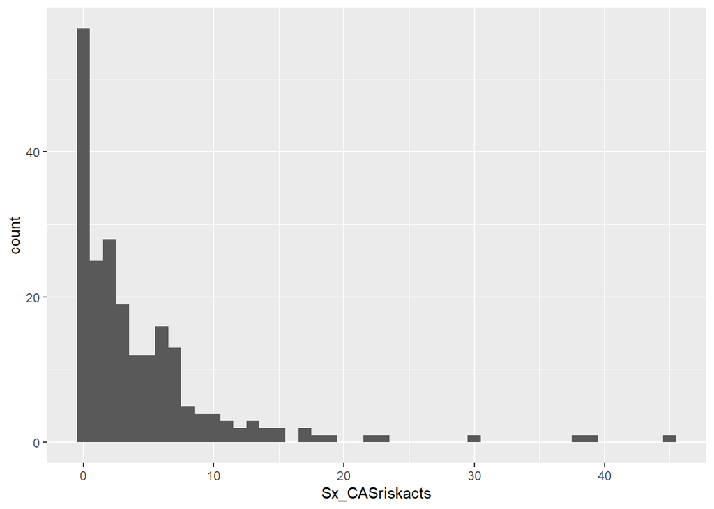

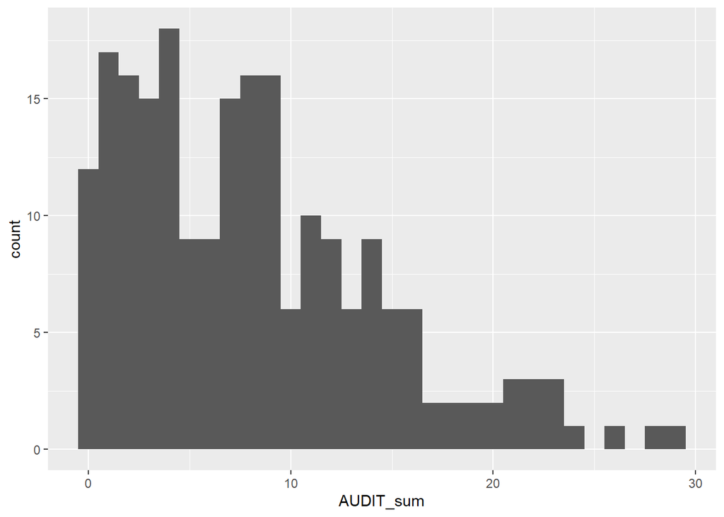

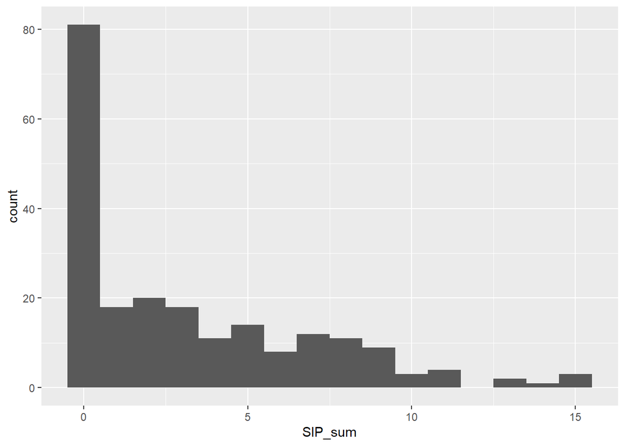

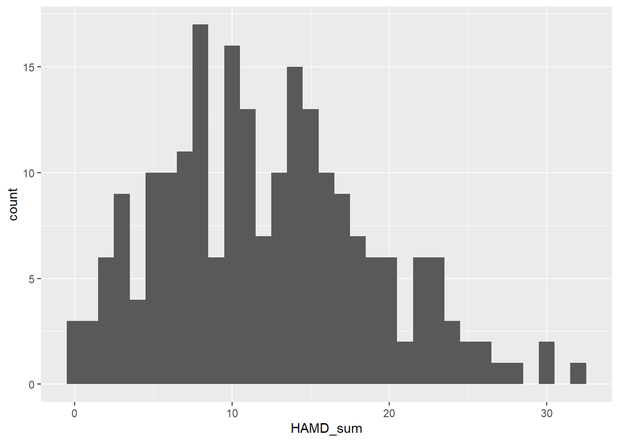

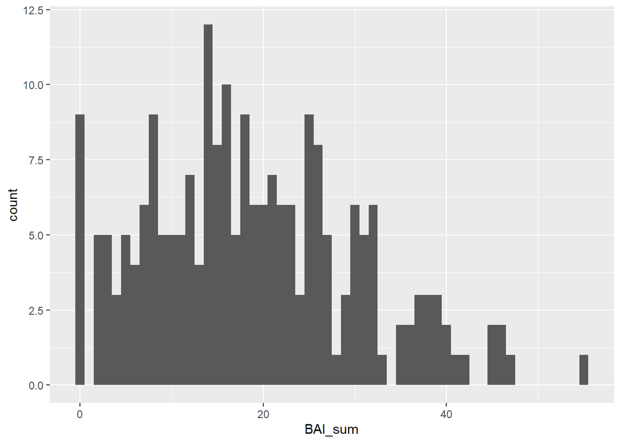

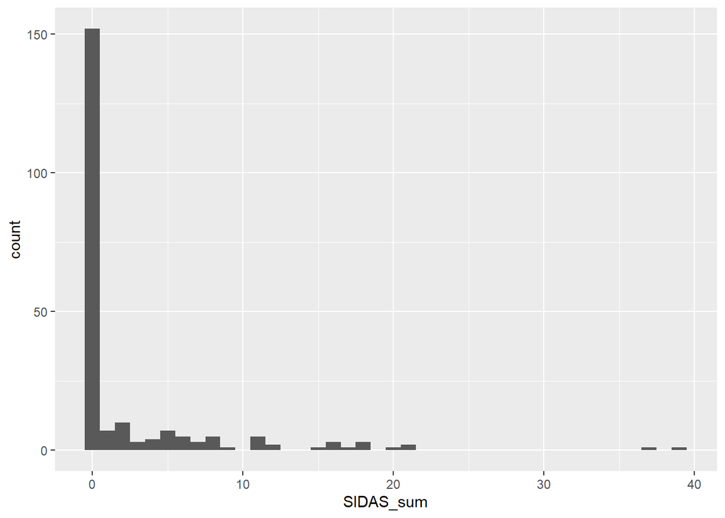

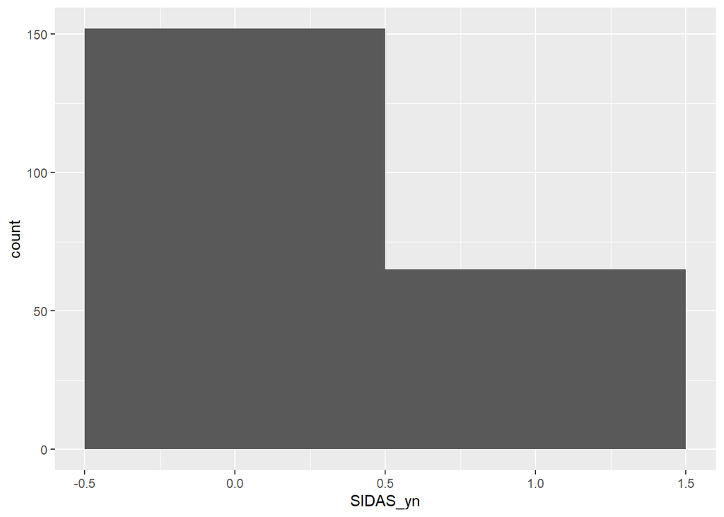

```r
plot_outcomes_sum <- function(data, outcome_vars) {
  plots <- map(outcome_vars, function(var) {
    var_sym <- sym(var)
    data %>%
      ggplot(aes(x = !!var_sym)) +
      geom_histogram(binwidth = 1)
  })

  return(plots)
}

outcome_vars_sum <- c("Sx_CASriskacts", "AUDIT_sum", "SIP_sum", "HAMD_sum", "BAI_sum", "SIDAS_sum", "SIDAS_yn")
plot_outcomes_sum(apps_outcome, outcome_vars_sum)
```

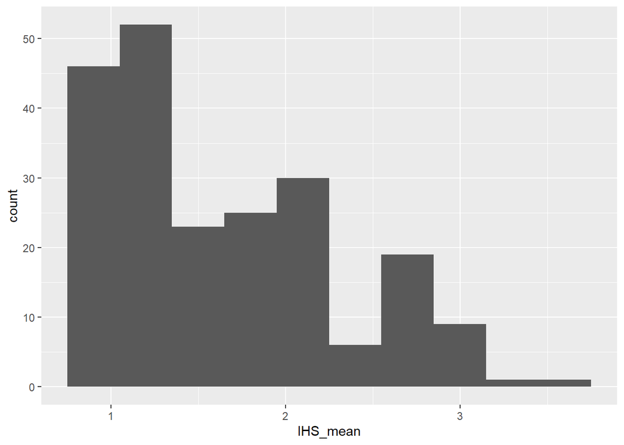

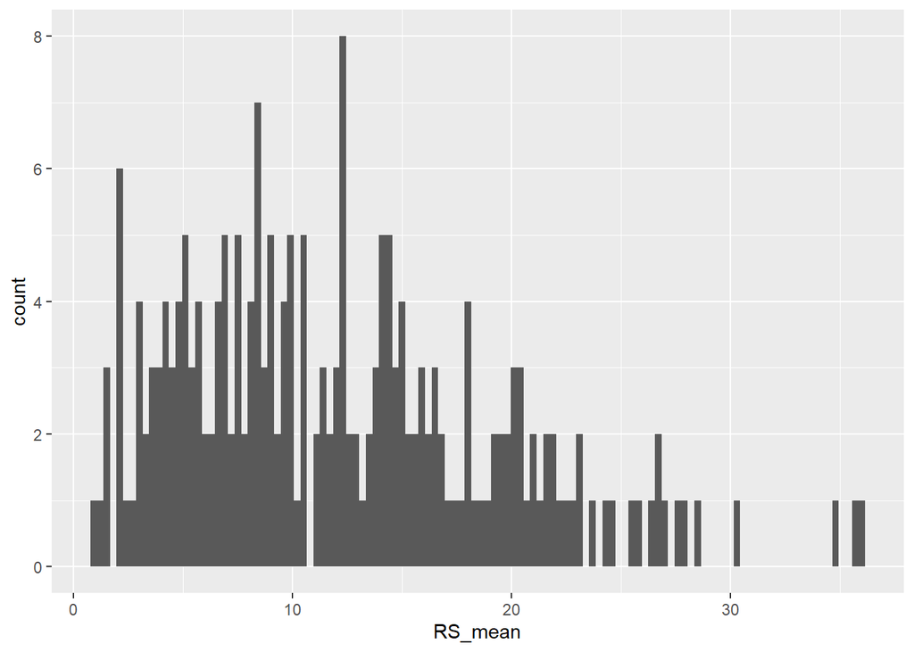

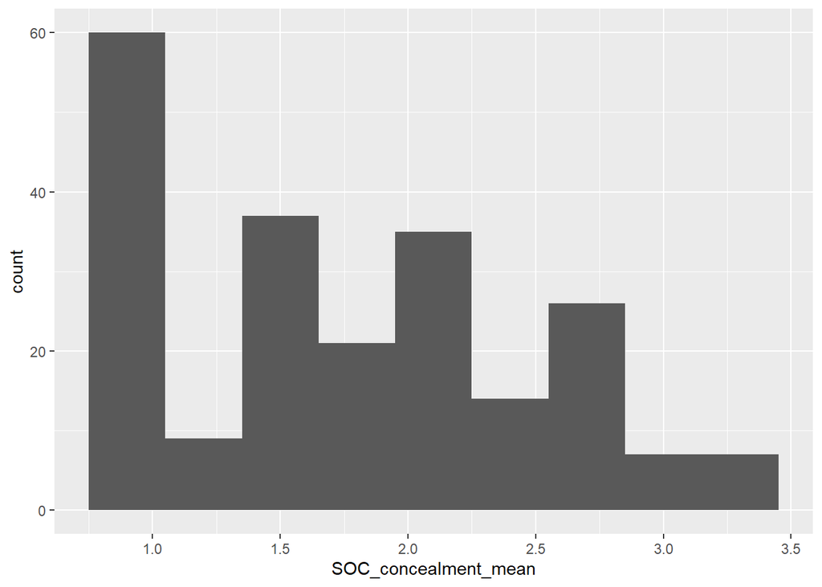

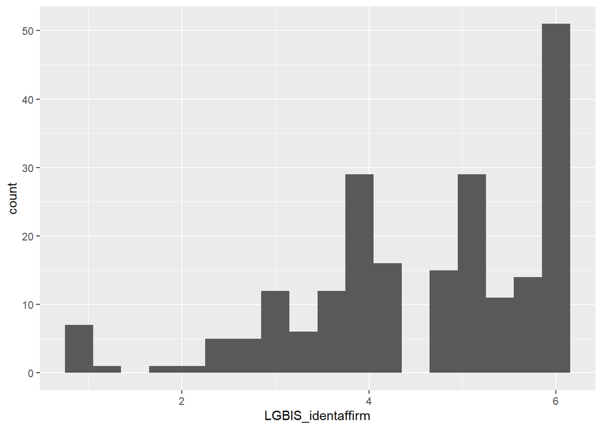

```r
plot_outcomes_mean <- function(data, outcome_vars) {
  plots <- map(outcome_vars, function(var) {
    var_sym <- sym(var)
    data %>%
      ggplot(aes(x = !!var_sym)) +
      geom_histogram(binwidth = 0.3)
  })

  return(plots)
}

outcome_vars_mean <- c("IHS_mean", "RS_mean", "SOC_concealment_mean", "LGBIS_identaffirm")
plot_outcomes_mean(apps_outcome, outcome_vars_mean)
```

# Change trajectories

## Individual plots

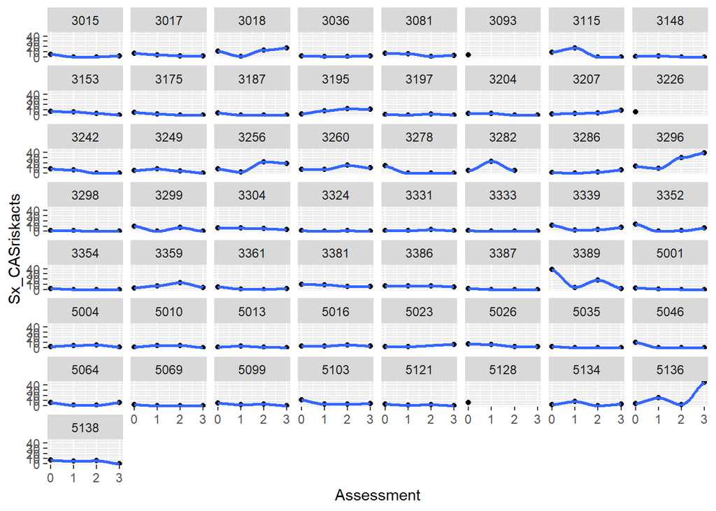

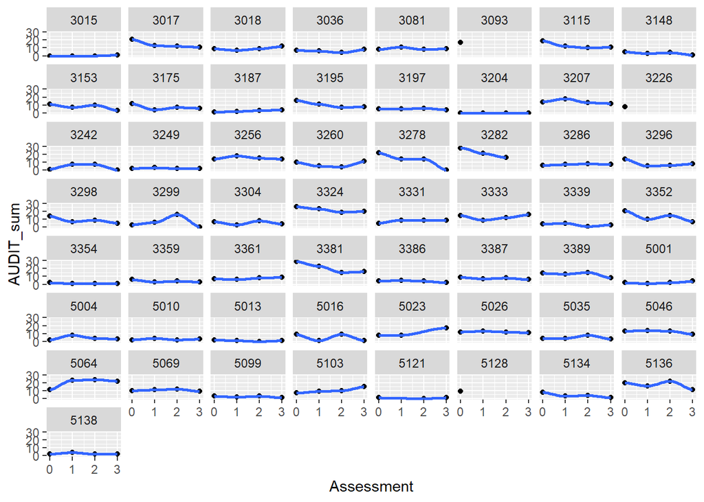

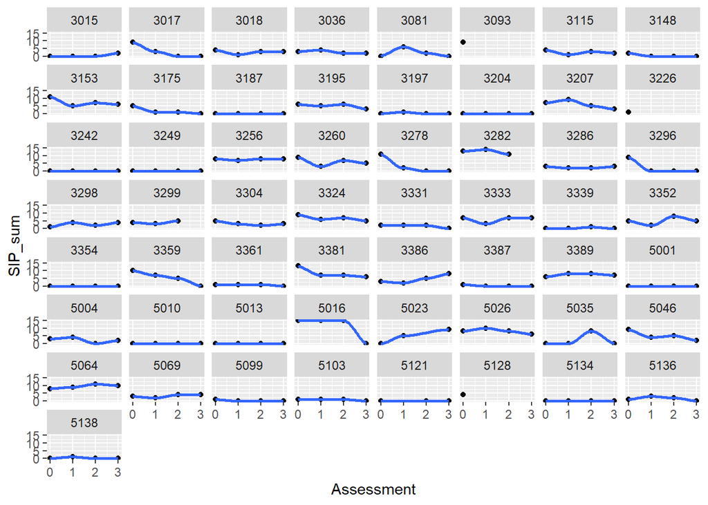

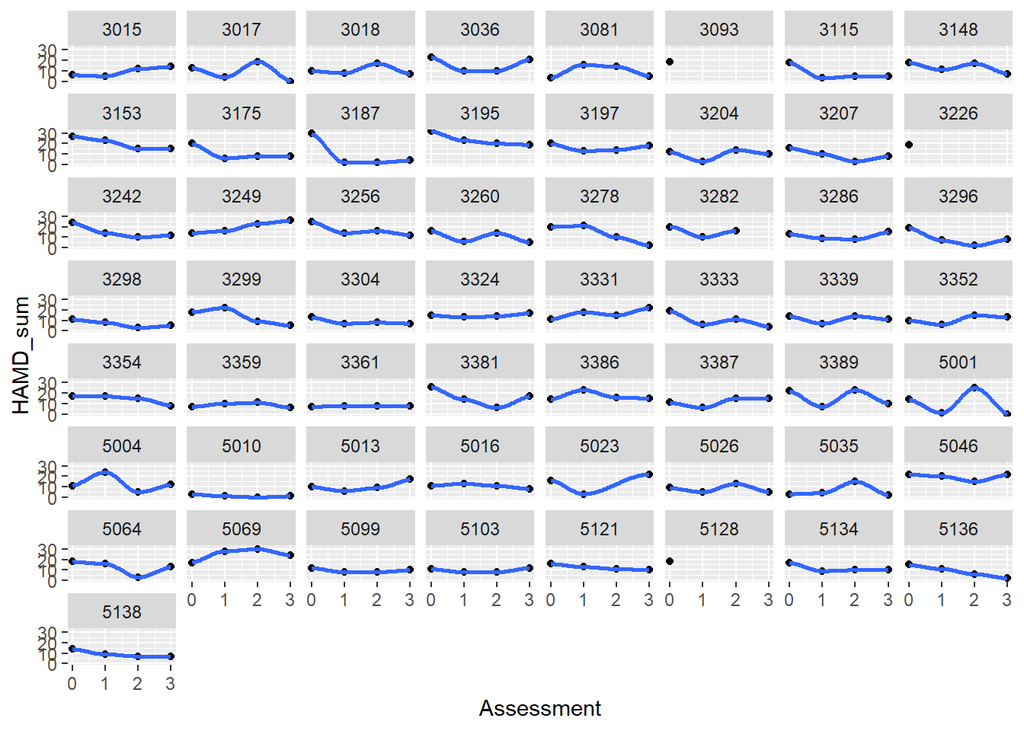

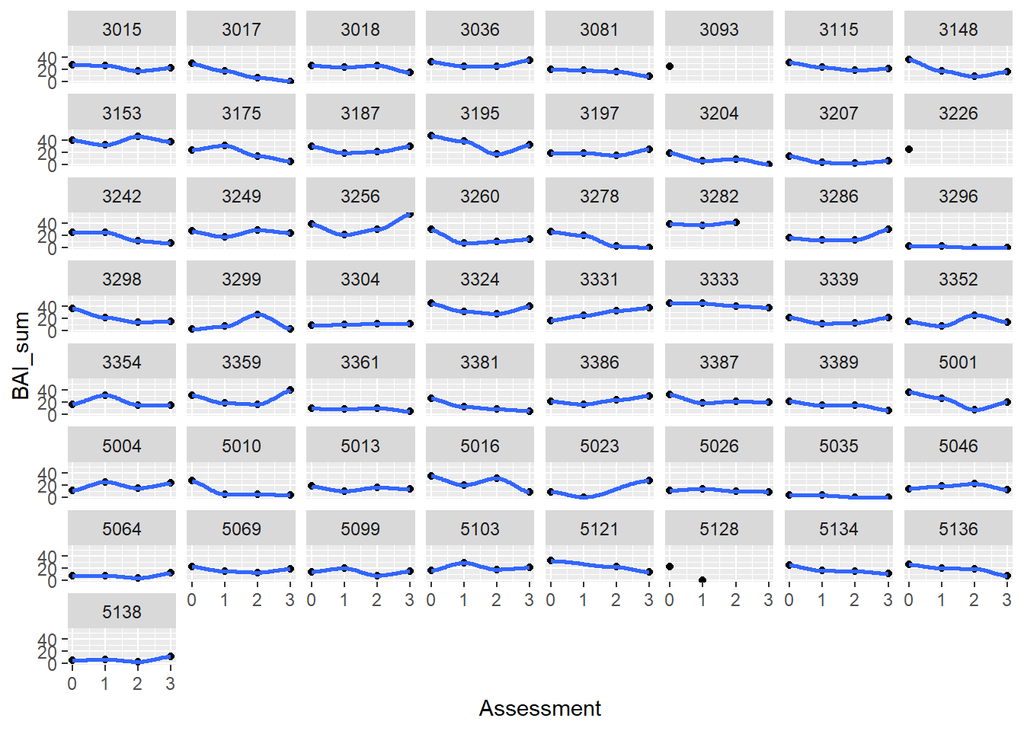

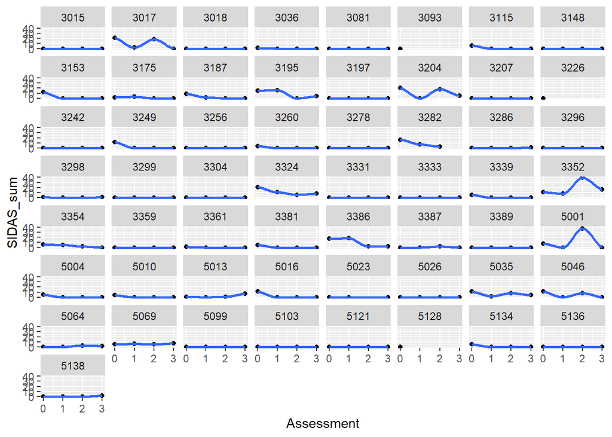

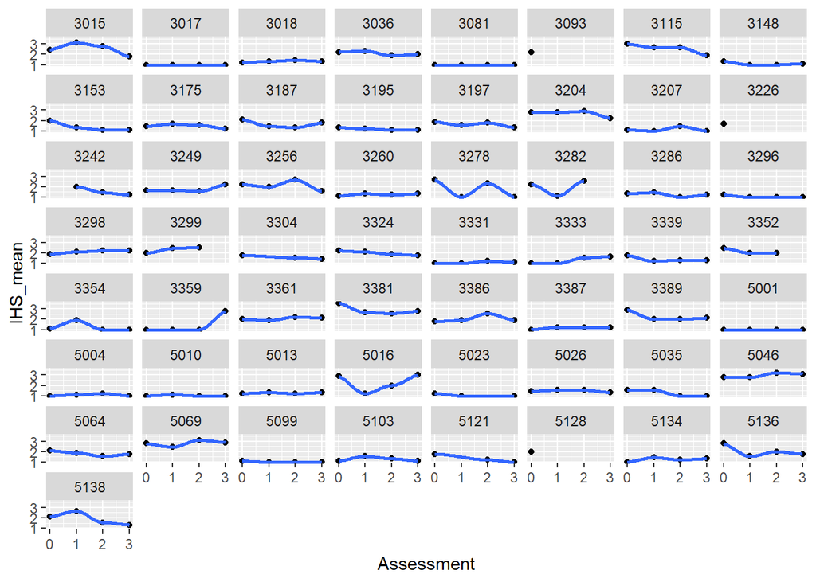

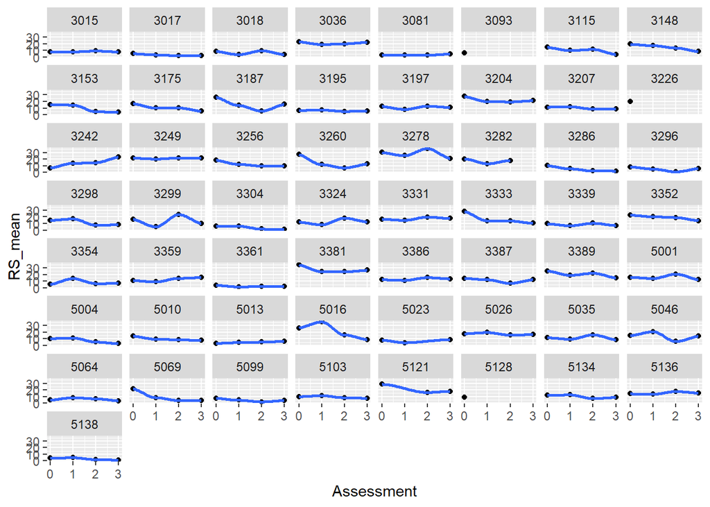

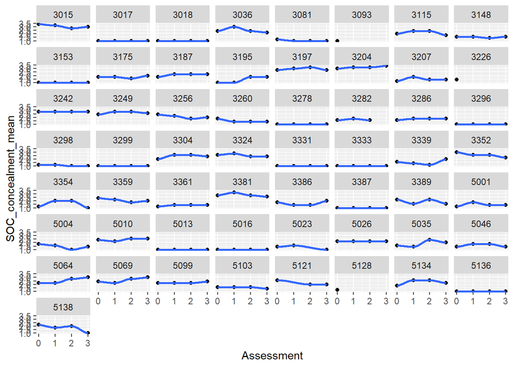

```r
individ_trajs <- function(data, outcome_vars) {
  plots <- map(outcome_vars, function(var) {
    var_sym <- sym(var)
    data |>
      ggplot(aes(x = Assessment, y = !!var_sym)) +
      geom_point() +
      stat_smooth(method = "loess", se = FALSE) +
      facet_wrap(~ ParticipantID)
  })

  return(plots)
}

outcome_vars <- c("Sx_CASriskacts", "AUDIT_sum", "SIP_sum", "HAMD_sum", "BAI_sum", "SIDAS_sum", "IHS_mean", "RS_mean", "SOC_concealment_mean")
individ_trajs(apps_outcome, outcome_vars)
```

### Spaghetti plots

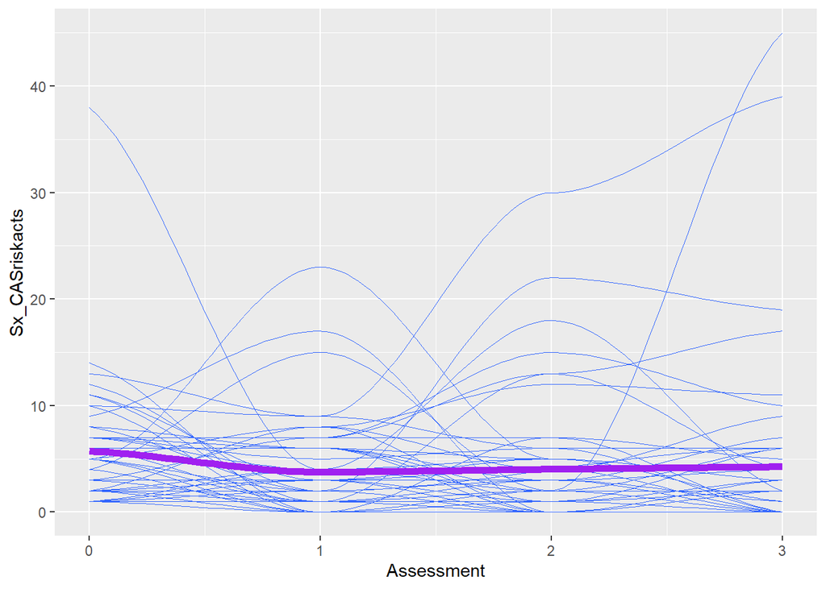

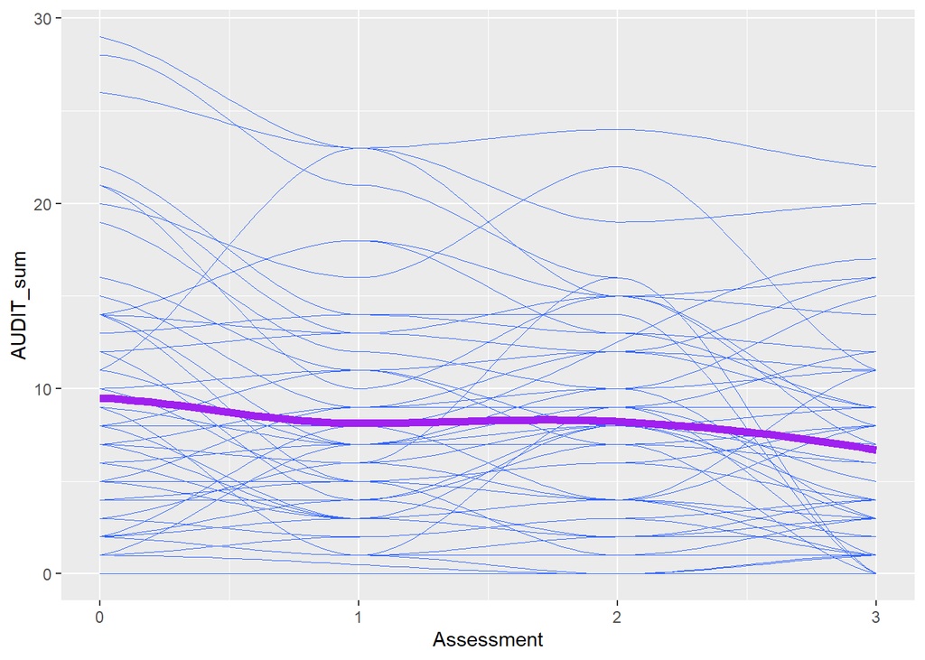

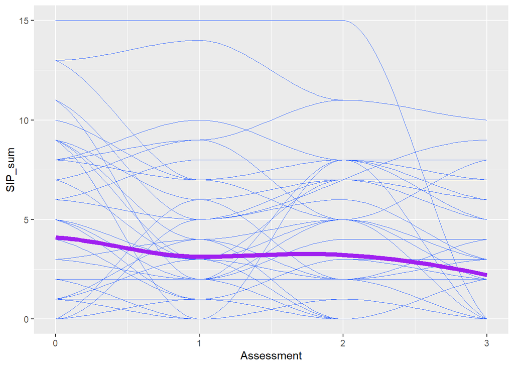

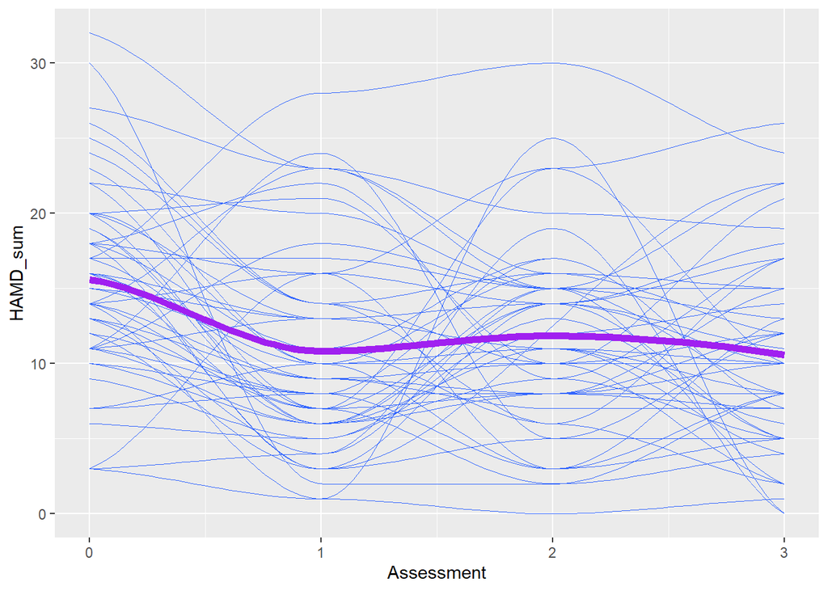

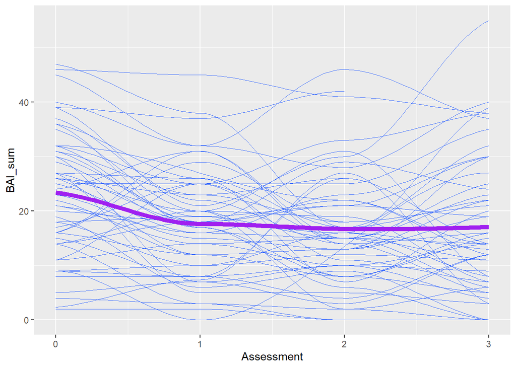

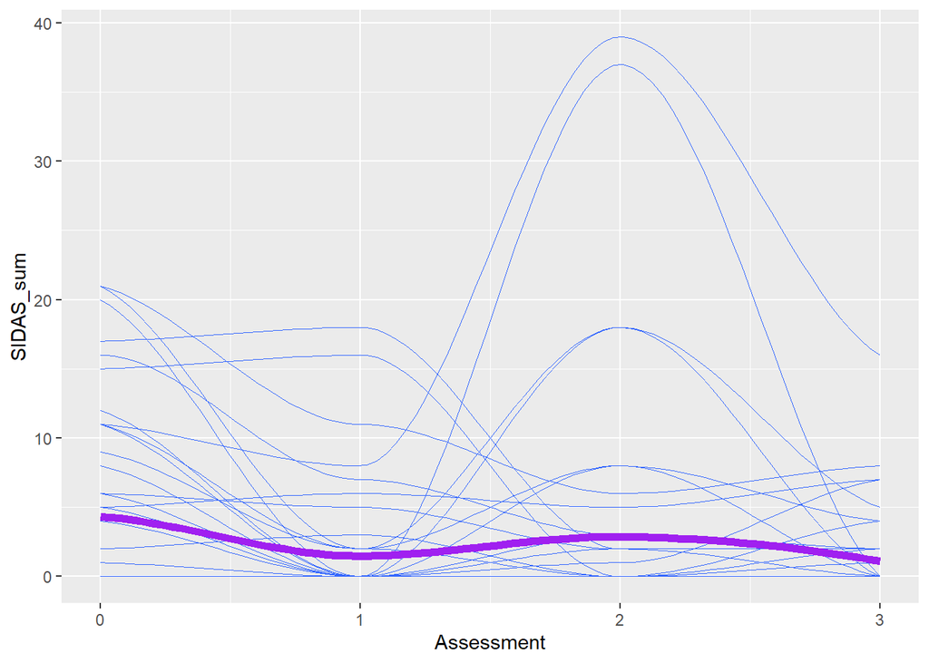

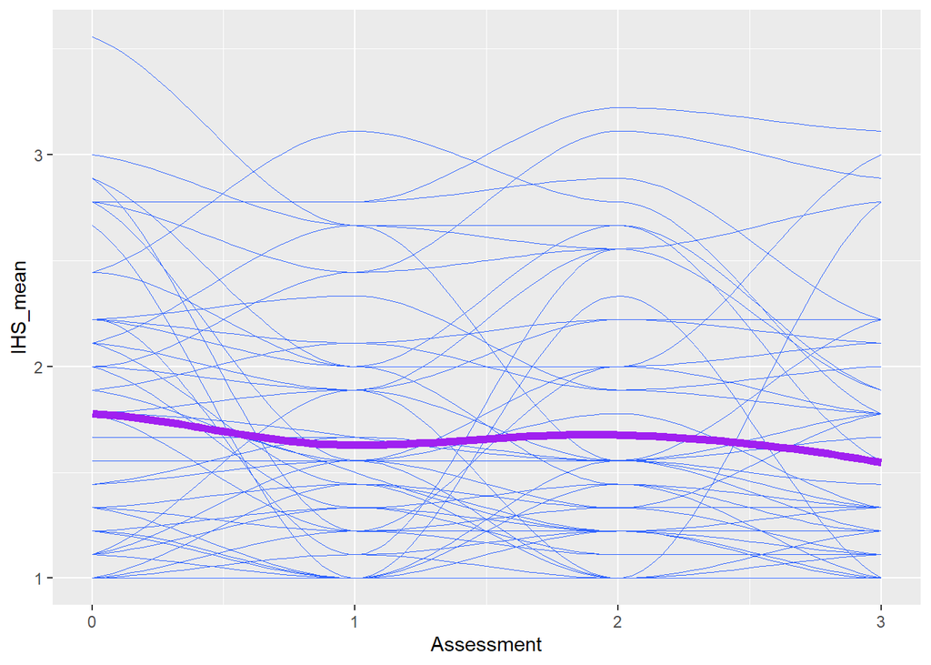

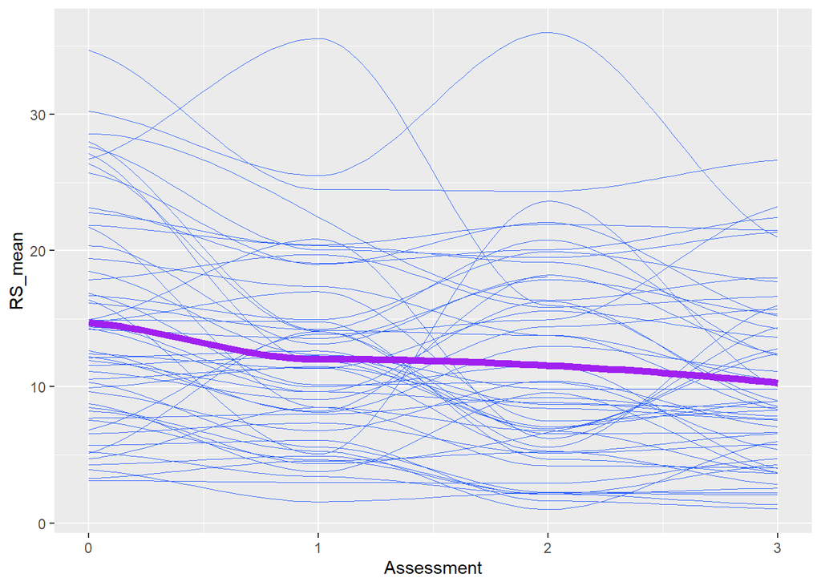

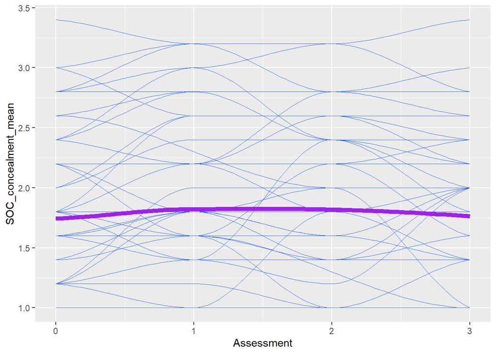

```r
spaghetti <- function(data, outcome_vars) {
  plots <- map(outcome_vars, function(var) {
    var_sym <- sym(var)
    data |>
      ggplot(aes(x = Assessment, y = !!var_sym)) +
      stat_smooth(aes(group = ParticipantID),
              method = "loess", se = F, size = 1/16) +
      stat_smooth(method = "loess", se = F, size = 2, color = "purple")
  })

  return(plots)
}

spaghetti(apps_outcome, outcome_vars)
```